# Voltage Related Columns

2023-10-24

```r
data1=read.csv("C:/Users/KDIVA/OneDrive/Desktop/Intro_to_data_science_project/dataset.csv")
colnames(data1)
```

```
##  [1] "X"
##  [2] "Unnamed..0"
##  [3] "GPS.Time"
##  [4] "Device.Time"
##  [5] "Longitude"
##  [6] "Latitude"
##  [7] "GPS.Speed..Meters.second."
##  [8] "Horizontal.Dilution.of.Precision"
##  [9] "Altitude"
## [10] "Bearing"
## [11] "G.x."
## [12] "G.y."
## [13] "G.z."
## [14] "G.calibrated."
## [15] "X0.100kph.Time.s."
```

[output cut: 72 more lines]

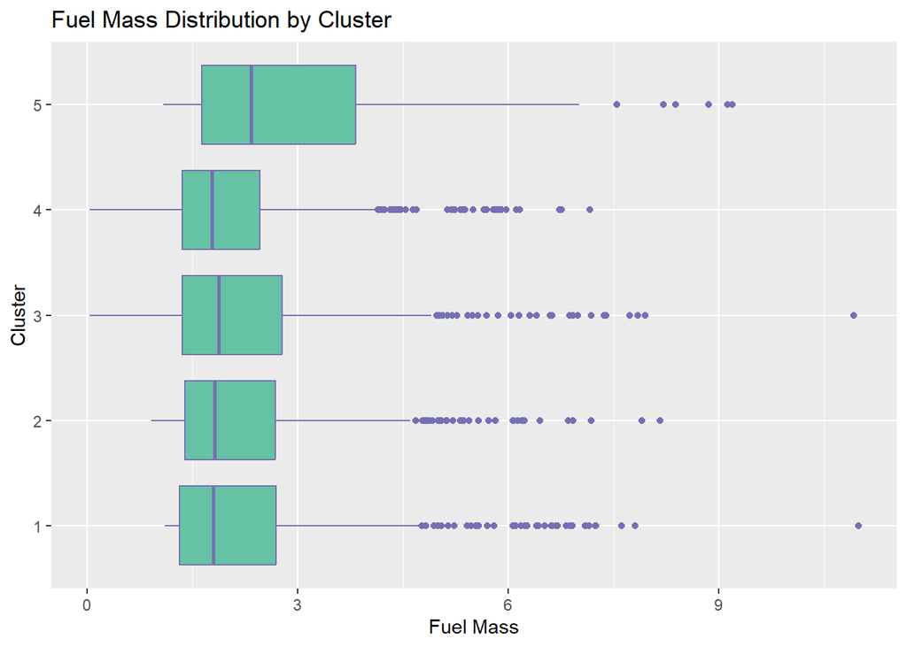

```r
data1$Cluster=as.factor(data1$Cluster)
library(ggplot2)
ggplot(data1, aes(x = Fuel_mass, y = Cluster)) +
  geom_boxplot(fill = "#66c2a5", color = "#7570b3") +
  labs(title = "Fuel Mass Distribution by Cluster", x = "Fuel Mass", y = "Cluster")
```

Clusters- 1,2 and 3 are similar. The analysis would be done such that the driver should avoid cluster 5 as it has the highest fuel mass consumption.

O2 Volts Bank 1 Sensor 1 (V):

This is the voltage output of the first oxygen sensor in Bank 1.

W.R.T Fuel Consumption:

This sensor provides feedback on the air-fuel mixture. Proper mixture leads to better fuel economy. The mixture should not be too lean or too rich.

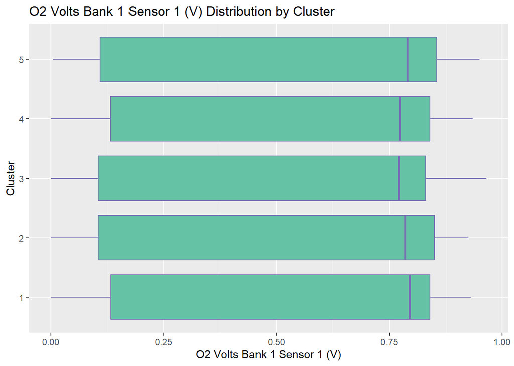

```r
ggplot(data1, aes(x = O2.Volts.Bank.1.sensor.1.V., y = Cluster)) +
  geom_boxplot(fill = "#66c2a5", color = "#7570b3") +
  labs(title = "O2 Volts Bank 1 Sensor 1 (V) Distribution by Cluster", x = "O2 Volts Bank 1 Sensor 1 (V)", y = "Cluster")
```

```r
ci_list <- list()

for (cluster_id in unique(data1$Cluster)) {
  subset_data <- data1[data1$Cluster == cluster_id, ]
  ci <- t.test(subset_data$O2.Volts.Bank.1.sensor.1.V.)
  ci_list[[as.character(cluster_id)]] <- ci$conf.int
}

print(ci_list)
```

```
## $`2`
## [1] 0.5090679 0.5726126
## attr(,"conf.level")
## [1] 0.95
##
## $`3`
## [1] 0.5037036 0.5734392
## attr(,"conf.level")
## [1] 0.95
##
## $`4`
## [1] 0.5319163 0.5937793
## attr(,"conf.level")
## [1] 0.95
##
## $`1`
## [1] 0.5431888 0.6057935
## attr(,"conf.level")
## [1] 0.95
##
## $`5`
## [1] 0.5267993 0.5946848
## attr(,"conf.level")
## [1] 0.95
```

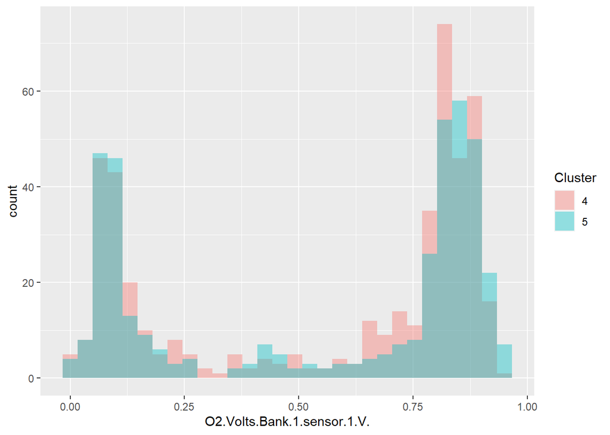

```r
data_o2_sen1 <- data1[data1$Cluster == "4" | data1$Cluster == "5",]
ggplot(data_o2_sen1, aes(x = O2.Volts.Bank.1.sensor.1.V., fill = Cluster)) +
  geom_histogram(position = "identity", alpha = 0.4)
```

There is no clear right or left shift. So, we bifercated the column into greater than 0.45 and less than 0.45 to do further analysis.

```r
less_than_045 <- subset(data1, O2.Volts.Bank.1.sensor.1.V. < 0.45)



ci_list <- list()

for (cluster_id in unique(less_than_045$Cluster)) {
  subset_data <- less_than_045[less_than_045$Cluster == cluster_id, ]
  ci <- t.test(subset_data$O2.Volts.Bank.1.sensor.1.V.)
  ci_list[[as.character(cluster_id)]] <- ci$conf.int
}

print(ci_list)
```

```
## $`4`
## [1] 0.1134342 0.1424804
## attr(,"conf.level")
## [1] 0.95
##
## $`3`
## [1] 0.1080701 0.1346931
## attr(,"conf.level")
## [1] 0.95
##
## $`2`
## [1] 0.1073881 0.1323027
## attr(,"conf.level")
## [1] 0.95
##
## $`1`
## [1] 0.1179074 0.1505926
## attr(,"conf.level")
## [1] 0.95
##
## $`5`
## [1] 0.1066661 0.1376760
## attr(,"conf.level")
## [1] 0.95
```

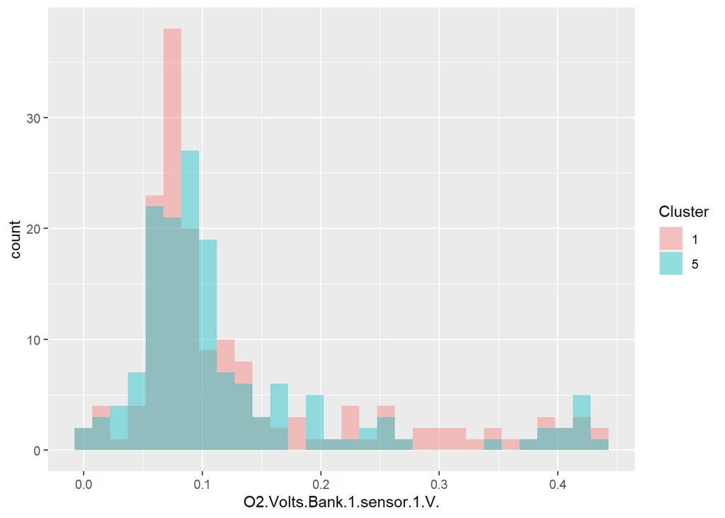

```r
data_o2_lower <- less_than_045[less_than_045$Cluster == "1" | less_than_045$Cluster == "5",]
ggplot(data_o2_lower, aes(x = O2.Volts.Bank.1.sensor.1.V., fill = Cluster)) +
  geom_histogram(position = "identity", alpha = 0.4)
```

Observation:

There is a right shift from cluster 5[C.I -0.10 to 0.13] to cluster 1[C.I -0.11 to 0.15]

```r
greater_than_045 <- subset(data1, O2.Volts.Bank.1.sensor.1.V. > 0.45)



ci_list <- list()

for (cluster_id in unique(greater_than_045$Cluster)) {
  subset_data <- greater_than_045[greater_than_045$Cluster == cluster_id, ]
  ci <- t.test(subset_data$O2.Volts.Bank.1.sensor.1.V.)
  ci_list[[as.character(cluster_id)]] <- ci$conf.int
}

print(ci_list)
```

```
## $`2`
## [1] 0.8158225 0.8330317
## attr(,"conf.level")
## [1] 0.95
##
## $`3`
## [1] 0.7995539 0.8219053
## attr(,"conf.level")
## [1] 0.95
##
## $`4`
## [1] 0.7929361 0.8146652
## attr(,"conf.level")
## [1] 0.95
##
## $`1`
## [1] 0.8062331 0.8252053
## attr(,"conf.level")
## [1] 0.95
##
## $`5`
## [1] 0.8062455 0.8300093
## attr(,"conf.level")
## [1] 0.95
```

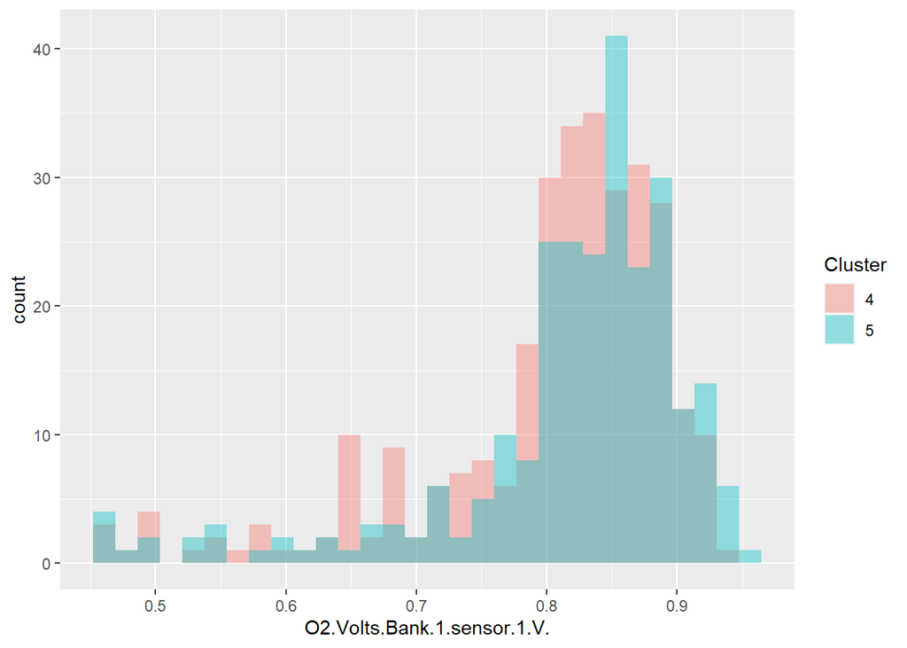

```r
data_o2_upper <- greater_than_045[greater_than_045$Cluster == "4" | greater_than_045$Cluster == "5",]
ggplot(data_o2_upper, aes(x = O2.Volts.Bank.1.sensor.1.V., fill = Cluster)) +
  geom_histogram(position = "identity", alpha = 0.4)
```

Observation:

There is a left shift from cluster 5[C.I -0.80 to 0.83] to cluster 4[C.I -0.79 to 0.81]. We can say that the column O2 Volts Bank 1 Sensor 1 is not a signifiant factor which affects Fuel consumption.